# Exam 1

# Part I: Estimating probabilities

Remember to load the `mosaic` package first:

```r
library(mosaic)
options(digits = 4)
library(pander)
```

## chile referendum data

In this part we will use the dataset `chile`. Remember to read the [description](http://www.rdocumentation.org/packages/car/functions/chile) of the dataset as well as the [Wikipedia](https://en.wikipedia.org/wiki/chilean_national_plebiscite,_1988) entry about the background.

```r
Chile <- read.table("http://asta.math.aau.dk/dan/static/datasets?file=Chile.dat", header=TRUE, quote="\"")
```

NB: This dataset has several missing values (`NA`). To remove these when you use `tally` you can add the argument `useNA = "no"`.

- Do a cross tabulation of the variables `vote` and `sex`.
1. Chile dataset has 2700 obs. After removing the missing values 2500 remain.
2. Cross tabulation in percentage

```r
chile<-tally(~vote+sex,data=Chile, useNA="no")
n<-sum(chile)
n
```

```
## [1] 2532
```

```r
chile<-tally(~vote+sex,data=Chile, useNA="no", format="percent")
chile
```

```
##     sex
## vote      F      M
##    A  4.107  3.278
##    N 14.336 20.774
##    U 14.297  8.926
##    Y 18.957 15.324
```

- Estimate the probability of `vote=N`.

```r
sum(chile[2,1:2])
```

```
## [1] 35.11
```

```r
pi<-14.336+20.774
pi
```

```
## [1] 35.11
```

- Make a 95% confidence interval for the probability of `vote=N`.

```r
se=sqrt((pi/100*(1-pi/100))/n)
z = qdist("norm", 1-0.05/2) #Since qdist calculates the probability not taking into account the absolute value of z, for the left probability we obtain:
```

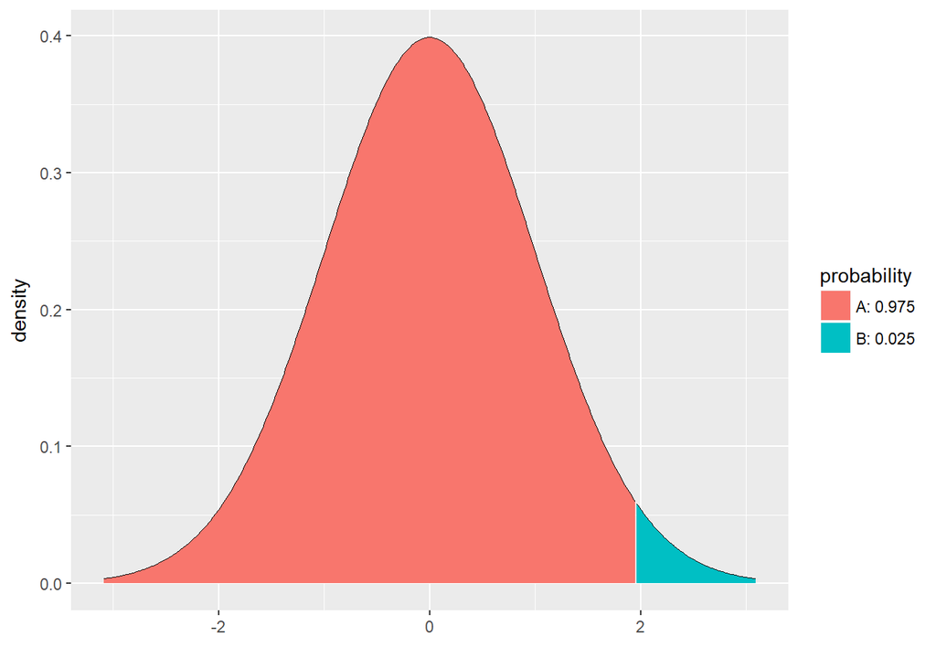

```r
z
```

```
## [1] 1.96
```

```r
piInt= pi+z*100*c(-se,se) #100 times z since we are giving the conf int in percentage.
piInt
```

```
## [1] 33.25 36.97
```

```r
prop.test(~ vote, data = Chile, correct = FALSE, success= "N")
```

```
##
##  1-sample proportions test without continuity correction
##
## data:  Chile$vote  [with success = N]
## X-squared = 220, df = 1, p-value <2e-16
## alternative hypothesis: true p is not equal to 0.5
## 95 percent confidence interval:
##  0.3328 0.3699
## sample estimates:
##      p
## 0.3511
```

- Estimate the probability of `vote=N` given that `sex=F`.

```r
tally(~vote+sex,data=Chile, useNA="no",format="percent",margin=1)
```

```
##        sex
## vote          F       M   Total
##   A       4.107   3.278   7.385
##   N      14.336  20.774  35.111
##   U      14.297   8.926  23.223
##   Y      18.957  15.324  34.281
##   Total  51.698  48.302 100.000
```

```r
piCond<-14.336/(51.698)
piCond
```

```
## [1] 0.2773
```

- What would these probabilities satisfy if `vote` and `sex` were statistically independent?

  This fact would mean that P(`vote`) does not depend on P(`sex`) applying this: P(`vote`|P`sex`)=P(`vote`)*P(`sex`).

```r
#P(`vote=N`)
pi
```

```
## [1] 35.11
```

```r
#P(`sex=F`)
pif<-51.698
#P(P`vote`)*P(`sex`)
pi*0.01*pif*0.01
```

```
## [1] 0.1815
```

```r
#Whereas P(P`vote`|P`sex`)
piCond
```

```
## [1] 0.2773
```

```r
#So the vote is conditioned by the sex
```